# CMPT 459.1-19. Programming Assignment 2

### K-Nearest Neighbors

**[Task 10]** (5 marks): Create a K-Nearest Neighbors model using caret’s “train” function with the method “knn” and 10-fold cross validation. Use the function `modelLookup("knn")` to see the available optimization parameters, try at least ten different k values and please save the caret’s “train” results on an object “knn”.

Also remember to now use “train_selec”.

```r
modelLookup("knn")
```

|  | model | parameter | label | forReg | forClass | probModel |
| --- | --- | --- | --- | --- | --- | --- |
| 1 | knn | k | #Neighbors | TRUE | TRUE | TRUE |

```r
set.seed(1)
knn <- train(
            Defense ~ .,
            data = train_selec,
            method = "knn",
            tuneGrid = expand.grid(k = c(2, 3, 4, 5 ,7, 10 ,15,20,25,30)),
            trControl = trainControl(method = "cv", number = 10) # Add Cross-Validation, 10 folds
)
```

Show the results for your modeling:

```r
knn
```

```
k-Nearest Neighbors

8968 samples
  15 predictor
   2 classes: 'No', 'Yes'

No pre-processing
Resampling: Cross-Validated (10 fold)
Summary of sample sizes: 8070, 8071, 8072, 8070, 8071, 8071, ...
Resampling results across tuning parameters:

  k   Accuracy   Kappa
   2  0.7677285  0.5354640
   3  0.7630429  0.5260926
   4  0.7787660  0.5575374
   5  0.7977225  0.5954490
   7  0.7928159  0.5856328
  10  0.7979474  0.5958946
  15  0.7989493  0.5978967
  20  0.7969445  0.5938866
  25  0.7938214  0.5876376
  30  0.7910334  0.5820596

Accuracy was used to select the optimal model using the largest value.
The final value used for the model was k = 15.
```

Plot the results for each `k` tested:

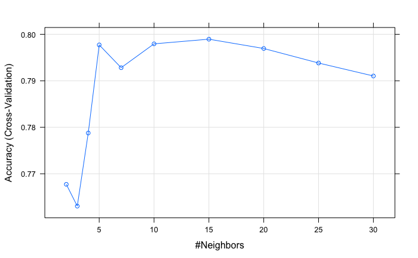

```r
plot(knn)
```

**[Task 11]** (8 marks): Please answer the following question: Why did K-NN get bad results? Explain.

- The training data was not normalized.
- K-NN assigns each unseen object to a class with the nearest mean vector using a distance function
- Since the dataset contains many different attributes, each of these attributes have a different range of values so their variance is different.
- This can cause the K-NN algorithm to favor toward attributes with wide ranges because a wider range of values increases the likelihood of an attribute being a neighbor to the unseen object that is being classified.

**[Task 12]** (3 marks): Now fix the problem with “knn”, using an additional argument of caret’s “train” function. Save the resulting model on “knn”.

```r
set.seed(1)
knn <- train(
            Defense ~ .,
            data = train_selec,
            method = "knn",
            tuneGrid = expand.grid(k = c(2, 3, 4, 5 ,7, 10 ,15,20,25,30)),
            preProcess = c("center","scale"),
            trControl = trainControl(method = "cv", number = 10) # Add Cross-Validation, 10 folds
)
```

Show the results for your modeling:

```r
knn
```

```
k-Nearest Neighbors

8968 samples
  15 predictor
   2 classes: 'No', 'Yes'

Pre-processing: centered (14), scaled (14)
Resampling: Cross-Validated (10 fold)
Summary of sample sizes: 8070, 8071, 8072, 8070, 8071, 8071, ...
Resampling results across tuning parameters:

  k   Accuracy   Kappa
   2  0.7813260  0.5626572
   3  0.7753057  0.5506155
   4  0.7913625  0.5827274
   5  0.8078660  0.6157340
   7  0.7996139  0.5992276
  10  0.8026285  0.6052542
  15  0.8116601  0.6233158
  20  0.8124399  0.6248745
  25  0.8141132  0.6282192
  30  0.8158991  0.6317926

Accuracy was used to select the optimal model using the largest value.
The final value used for the model was k = 30.
```

Plot the results for each `k` tested:

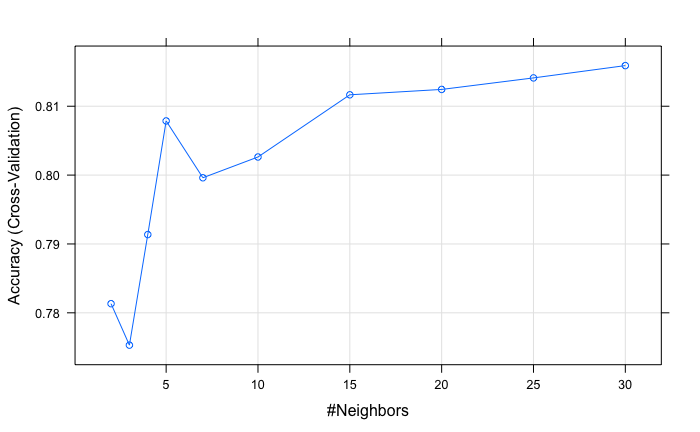

```r
plot(knn)
```

So far we’ve been using “Accuracy” as our main classification metric to get the best model. Let’s change that.

Please run the code below for a new function to be used.

```r
library(MLmetrics)
metrics_summary <- function(data, lev = NULL, model = NULL) {
  data <- as.data.frame(data)
  lvls <- levels(data$obs)
  f1_val <- F1_Score(y_pred = data$pred, y_true = data$obs, positive = lev[2])
  auc_val <- ModelMetrics::auc(ifelse(data$obs == lev[1], 0, 1), data[, lvls[2]])
  acc_val <- Accuracy(y_pred = data$pred, y_true = data$obs)
  prec_val <- Precision(y_pred = data$pred, y_true = data$obs, positive = lev[2])
  rec_val <- Recall(y_pred = data$pred, y_true = data$obs, positive = lev[2])
  c(F1 = f1_val, AUC = auc_val, Accuracy = acc_val, Precision = prec_val, Recall = rec_val)
}
```

**[Task 13]** (3 marks): Please copy and paste your last K-NN model building using caret’s “train”, and then replace your current `trControl` with `trControl = trainControl(method = "cv", number = 10, classProbs = TRUE, summaryFunction = metrics_summary)`. Also add the following new argument to “train” function: `metric = "F1"`. Please save the resulting model as “knn2”.

```r
set.seed(1)
knn2 <- train(
            Defense ~ .,
            data = train_selec,
            method = "knn",
            tuneGrid = expand.grid(k = c(2, 3, 4, 5 ,7, 10 ,15,20,25,30)),
            preProcess = c("center","scale"),
            trControl = trainControl(method = "cv", number = 10, classProbs = TRUE, summaryFunction = metrics_summary),
            metric = "F1"
)
```

Show the results for your modeling:

```r
knn2
```

```
k-Nearest Neighbors

8968 samples
  15 predictor
   2 classes: 'No', 'Yes'

Pre-processing: centered (14), scaled (14)
Resampling: Cross-Validated (10 fold)
Summary of sample sizes: 8070, 8071, 8072, 8070, 8071, 8071, ...
Resampling results across tuning parameters:

  k   F1         AUC        Accuracy   Precision  Recall
   2  0.7732164  0.8439216  0.7813260  0.8035941  0.7453607
   3  0.7664791  0.8703529  0.7753057  0.7979774  0.7375557
   4  0.7866766  0.8718017  0.7913625  0.8050004  0.7692183
   5  0.8057518  0.8778146  0.8078660  0.8149255  0.7968675
   7  0.7988547  0.8799607  0.7996139  0.8021382  0.7957530
  10  0.8038187  0.8848314  0.8026285  0.7993800  0.8084687
  15  0.8146172  0.8885733  0.8116601  0.8025464  0.8271924
  20  0.8163994  0.8907664  0.8124399  0.7998175  0.8338803
  25  0.8185972  0.8908868  0.8141132  0.7995622  0.8387841
  30  0.8206452  0.8913654  0.8158991  0.8003320  0.8421363

F1 was used to select the optimal model using the largest value.
The final value used for the model was k = 30.
```

Plot the results for each `k` tested:

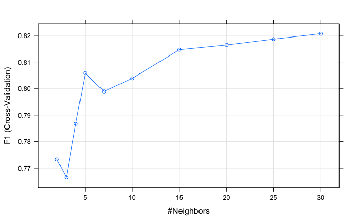

```r
plot(knn2)
```

**[Task 14]** (5 marks): Please answer the following questions:

- Based on F1 metric, did caret chose a different model from before when Accuracy was used?
- No, both knn2 and knn chose k=30
- Which model would you use? Explain why.
- I would use the knn model with F1 metric(knn2)
- A model can be highly accurate but have poor precision/poor recall
- For example, If we have 1000 people to predict who is suited to play defense where 990 aren’t suited, but 10 are suited, you can achieve 99% accuracy by predicting everyone isn’t suited to play defense but consequently you get 0% recall for those who are suited.
- In this task, it is important to predict who should go on defense and also avoid false positives(predict player should go on defense but shouldn’t)

## So F1 metric is useful since it considers both Precision and Recall.

### Support Vector Machines

**[Task 15]** (10 marks): Create a SVM model using caret’s “train” function. Choose one of the methods from “http://topepo.github.io/caret/train-models-by-tag.html#support-vector-machines”. Perform 10-fold cross validation and try different optimization parameters (`tuneGrid`) to get the best model you can. Please save the caret’s “train” results on object “svm”. **Method suggested: “svmLinear2”.**

Also remember to now use “train_selec”.

```r
set.seed(1)
svm <- train(
            Defense ~ .,
            data = train_selec,
            method = "svmLinear2",
            tuneGrid = expand.grid(cost = c(0.25, 0.50, 0.75, 1.00 )),
            trControl = trainControl(method = "cv", number = 10, classProbs = TRUE, summaryFunction = metrics_summary)
)
```

Show the results for your modeling:

```r
svm
```

```
Support Vector Machines with Linear Kernel

8968 samples
  15 predictor
   2 classes: 'No', 'Yes'

No pre-processing
Resampling: Cross-Validated (10 fold)
Summary of sample sizes: 8070, 8071, 8072, 8070, 8071, 8071, ...
Resampling results across tuning parameters:

  cost  F1         AUC        Accuracy   Precision  Recall
  0.25  0.8206833  0.8815774  0.8142276  0.7934271  0.8499458
  0.50  0.8207697  0.8815645  0.8143391  0.7935878  0.8499458
  0.75  0.8209847  0.8815465  0.8145622  0.7937959  0.8501690
  1.00  0.8211482  0.8815814  0.8146739  0.7937201  0.8506155

Accuracy was used to select the optimal model using the largest value.
The final value used for the model was cost = 1.
```

Show the final model:

```r
svm$finalModel
```

```
Call:
svm.default(x = as.matrix(x), y = y, kernel = "linear", cost = param$cost, probability = classProbs)


Parameters:
   SVM-Type:  C-classification
 SVM-Kernel:  linear
       cost:  1
      gamma:  0.07142857

Number of Support Vectors:  4076
```

Plot the results for each parameter tested:

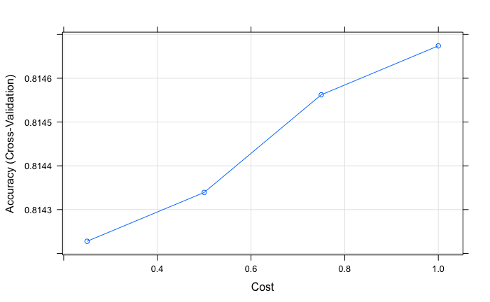

```r
plot(svm)
```

### Choosing the best model

Please run the following code to show 10-fold Cross Validation accuracy for all models:

```r
cv_metrics <- function(model){
  model$results[row.names(model$bestTune), 'Accuracy']
}
sapply(list(dt, lgr, knn, knn2, svm), cv_metrics)
```

```
[1] 0.7813324 0.8169026 0.8158991 0.8158991 0.8146739
```

**[Task 16]** (1 mark): Which model is the best and what was its 10-fold CV Accuracy?

- logistics regression(lgr) with accuracy 0.8169026

### Evaluating on test dataset

Please run the code below to evaluate the performance of all the best models (of their corresponding type) on the test dataset.

```r
data_metrics <- function(model, thedata){
  res <- predict(model, newdata = thedata, type = "prob")$Yes
  data <- data.frame(pred = ifelse(res >= 0.5, 'Yes', 'No'), obs = as.factor(thedata$Defense), Yes = res)
  lev = c('No', 'Yes')
  metrics_summary(data, lev)
}
sapply(list(dt, lgr, knn, knn2, svm), data_metrics, thedata=test)
```

```
               [,1]      [,2]      [,3]      [,4]      [,5]
F1        0.8404352 0.8519528 0.8544474 0.8544474 0.8527413
AUC       0.8442112 0.8846229 0.8864850 0.8864850 0.8834387
Accuracy  0.8040089 0.8184855 0.8195991 0.8195991 0.8190423
Precision 0.8543779 0.8677151 0.8606335 0.8606335 0.8664825
Recall    0.8269402 0.8367529 0.8483497 0.8483497 0.8394291
```

**[Task 17]** (3 marks): Looking at the test results, please answer the following questions: